# R Notebook

# Individual Responses

To better understand why certain sites express correlations in their N, P, and K response trajectories, we can look at the individual responses of species that constitute these community-level effects.

From existing work on nutrient enrichment (both in NutNet and other meta-analysis), there are a number of patterns that might be expected:

- Dominant species respond more positively to nutrient enrichment than non-dominants
- Certain functional groups (e.g. legumes) are likely to respond to P, K enrichment over others

These relationships may also give us more clues on what sort of site-level covariates might be interested.

Here, I’ve taken the individual coefficients estimated from part 2 and plotted them vs. a series of potential individual-level covariates. I’ve highlighted relationships between dominance and functional group here, but a bunch more exploration is possible.

In the process of calculating these, I’ve produced a “tuning table” that has a number of features that can also be used to subset the dataset prior to conducting these analyses:

- Pretrt presence / absence and cover
- Total observations over the course of sampling
- Pretrt dominance and control dominance (abundance / total observed cover)

# Plotting relationships

Across all three fertilization treatment pairs (N-P, N-K, and P-K), responses seem to be quite correlated. I’ve only showed correlations between the response to N enrichment (trt_N) and P enrichment (trt_P):

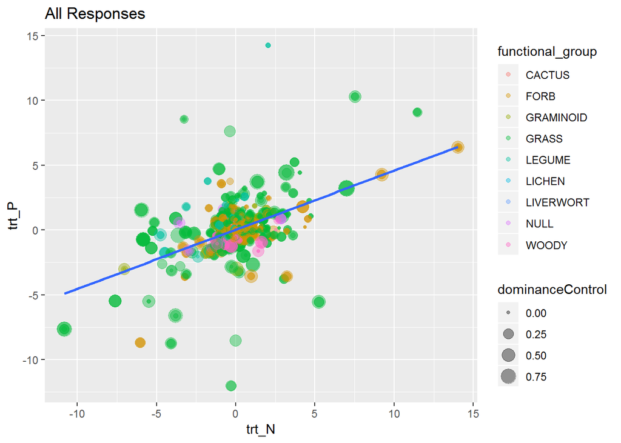

However, there is still a significant amount of site-to-site variation in the shape of this line, equivalent to the correlations we examined in part 2. If we examine sites across the N-P tradeoff distribution, we might be able to get a sense of what species drive community-level trends.

#### Sites highlighted:

- Pinjarra Hills - Most negative NP response correlation
- Sagehen - Median NP response correlation
- Konza - Strongest NP response correlation

Some sites seem to show evidence that certain functional groups may be skewing these relationships - Sagehen, for example, shows a legume species with high P affinity, but a weak positive response to N.

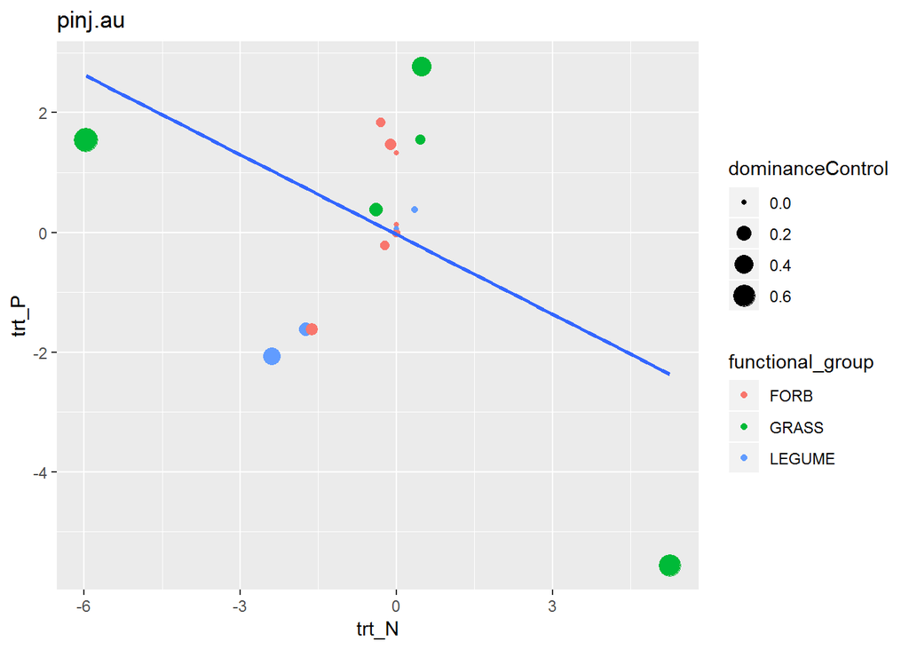

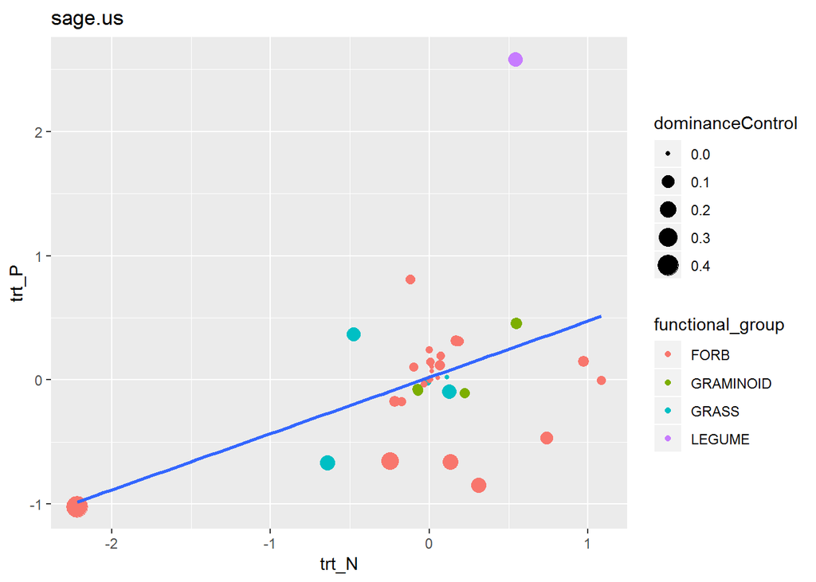

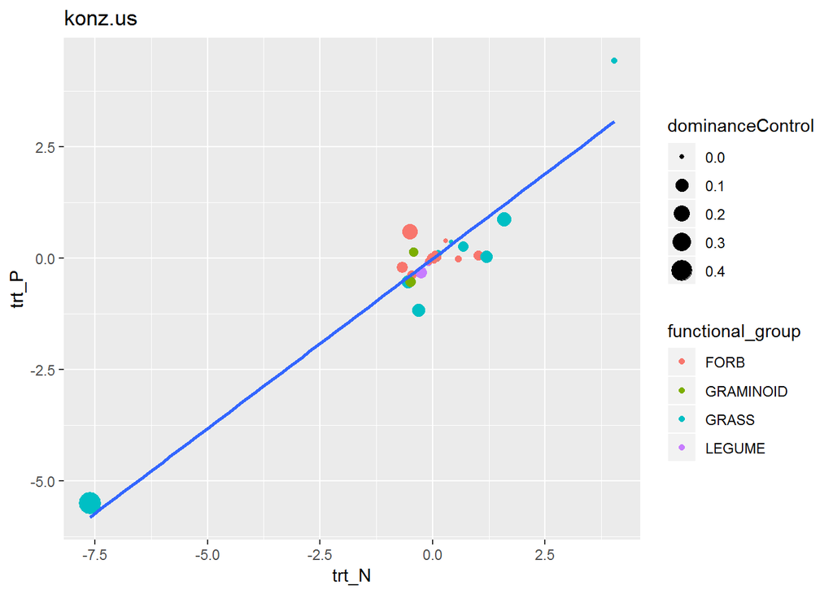

#### In a univariate perspective, there does not appear to be any significant correlation between functional group and response, however:

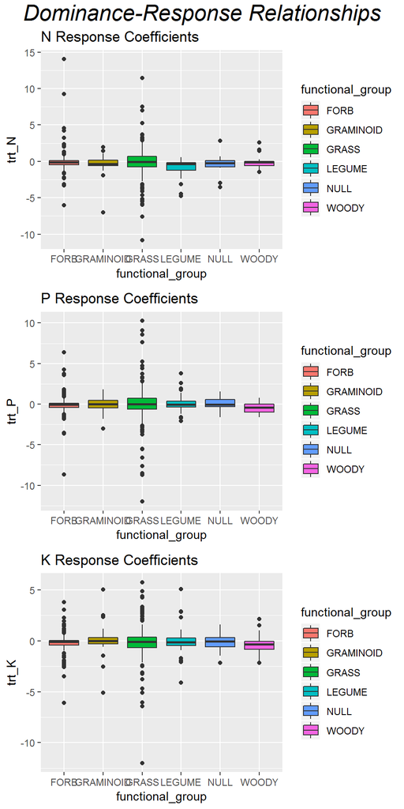

#### Nor are there strong relationships with dominance (proportional of total cover in control plots over all years)

[figure not shown]

#### However, some additional exploration suggests that while species tend to share similar responses to all nutrient additions, functional groups exhibit differences in their deviations from this overall relationship.

Legumes, for example, seem to have a higher affinity to P than would be predicted by their +N treatment responses (same with K enrichment), while grasses have slightly stronger N affinity.

These results, calculated by examining residuals relative to the overall trend, are not shown graphically.